# TRIGGER - GPS exploration

## Check accuracy

```
    0%    10%    20%    30%    40%    50%    60%    70%    80%    90%   100%
    -1     -1      4     15     20     53    100    100    100    100 167019
```

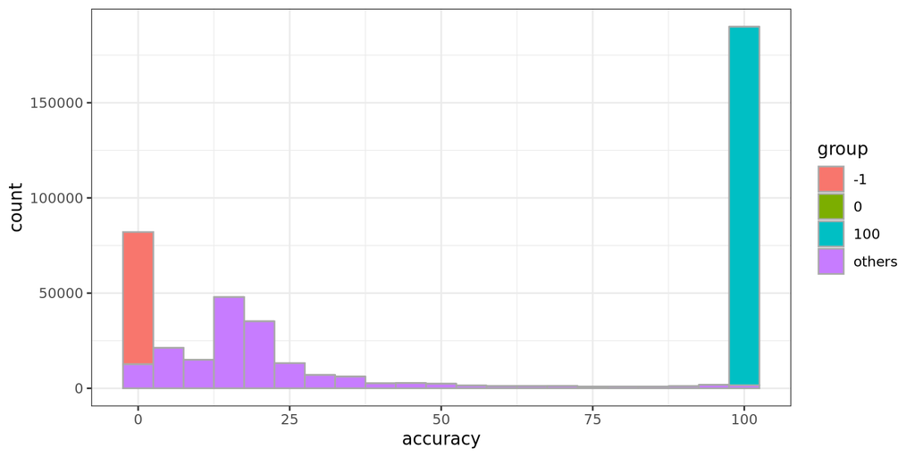

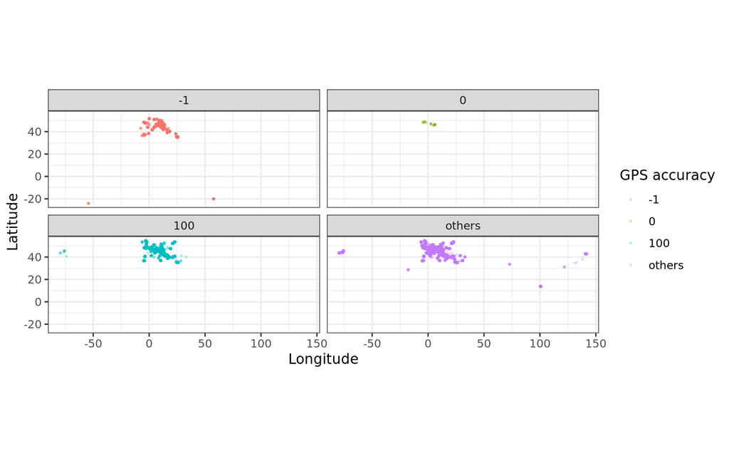

## Geographic grid

### Relationship with Copernicus ERA5-HEAT

Copernicus [ERA5-HEAT](https://cds.climate.copernicus.eu/datasets/derived-utci-historical) provides hourly Universal Thermal Climate Index (UTCI) estimates on a regular latitude-longitude grid with a spacing of **0.25° × 0.25°**.

This spacing represents angular differences between adjacent grid points. A 0.25° interval corresponds to approximately 27.8 km north–south ($40,000/360 \times 0.25 \approx 27.8$ km). East–west distances decrease with latitude as meridians converge toward the poles, reaching approximately 19.8 km at Bologna’s latitude ($27.8 \times \cos(44.5^\circ) \approx 19.8$ km).

To associate GPS observations with this geographic grid, each coordinate is rounded to the nearest multiple of 0.25°:

$$\phi_{\mathrm{grid}} = \frac{\operatorname{round}(4\phi)}{4}$$

$$\lambda_{\mathrm{grid}} = \frac{\operatorname{round}(4\lambda)}{4}$$

where $\phi$ and $\lambda$ represent the original GPS latitude and longitude, respectively.

This assigns each observation to a regular grid point based on geographic coordinates. It is equivalent to selecting the nearest grid point independently along each coordinate axis, rather than calculating the minimum geodesic distance.

The method assumes that the Copernicus data use the corresponding 0.25° grid alignment.

For visualization, each grid point is represented by a rectangular polygon extending ±0.125° in both latitude and longitude. These polygons are constructed geometrically and should not be interpreted as spatially uniform UTCI measurements.

## Grid coverage

Summarise GPS availability at each geographic grid point.

Three complementary indicators are calculated:

- `n_gps`: total number of GPS observations.
- `n_users`: number of distinct participants observed at the grid point.
- `n_user_days`: number of distinct participant-days represented at the grid point.

The number of GPS observations reflects sampling intensity, whereas participant and participant-day counts provide complementary measures of geographic coverage.

## 3D geographic visualization

### Polygon construction

Each grid point `(lon, lat)` is converted into a rectangular polygon with the following vertices:

| Vertex | Longitude | Latitude |
| --- | --- | --- |
| Southwest | lon − 0.125 | lat − 0.125 |
| Southeast | lon + 0.125 | lat − 0.125 |
| Northeast | lon + 0.125 | lat + 0.125 |
| Northwest | lon − 0.125 | lat + 0.125 |

The first vertex is repeated to close the polygon.

Polygons are stored as `sf` geometries using the geographic coordinate reference system EPSG:4326.

### Extrusion height and color

The square-root transformation reduces the visual dominance of highly sampled grid points.

Colors represent observation-count categories. Both height and color are visualization attributes and do not represent physical altitude or meteorological measurements.

### Interactive map

The geographic polygons are rendered as 3D extrusions using `mapgl`.

The map allows exploration of GPS sampling intensity, participant coverage and participant-day coverage across geographic grid points.

[interactive chart not shown]

## GPS coverage

Daily GPS availability is summarised by the number of observations and distinct hours recorded for each participant-day.

```
# A tibble: 1 × 6
  participants_n participant_days_n median_gps_n median_hours_n
           <int>              <int>        <dbl>          <dbl>
1            224              12486            8              3
# ℹ 2 more variables: single_gps_days_pct <dbl>, single_hour_days_pct <dbl>
```

### Daily observations

Distribution of GPS observations per participant-day, including days with a single observation.

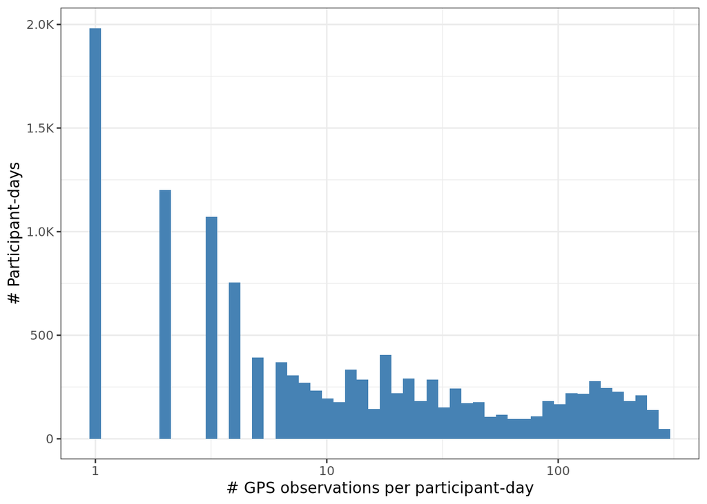

### Temporal coverage

Each tile represents a participant-day, coloured by the number of distinct hours with GPS observations. Participants are grouped by nationality.

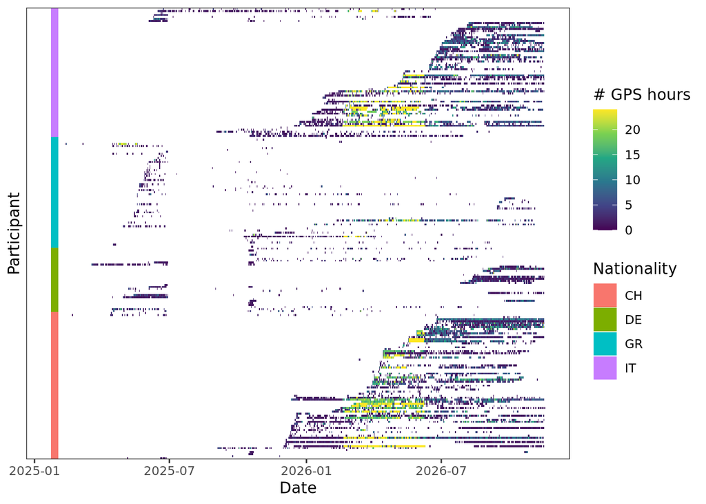

## GPS sampling frequency

Sampling intervals are calculated between consecutive observations for each participant, either across the entire monitoring period or within the same UTC calendar day.

### Sampling interval distribution

Overall intervals include gaps across days or months, whereas within-day intervals exclude gaps between different calendar days.

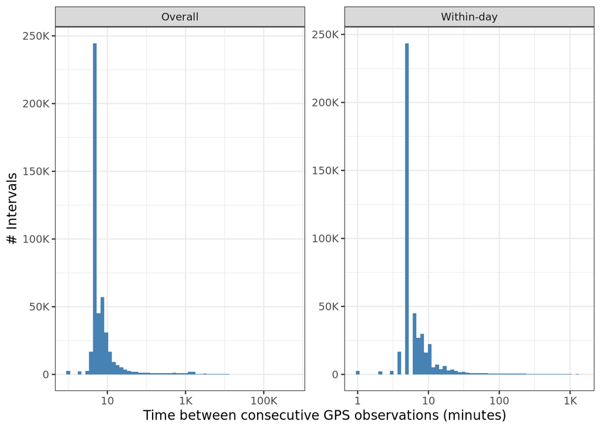